# Final Report - Group Q

Pranav Bhardwaj (pbhardwa), Bristow Richards (wrichard), Philippe Schicker (pschicke)

December 9th 2021

### Introduction

This analysis relies on the following five datasets:  
- `detained.csv.gz` - the gzipped csv file concerning detainees (AAPP)  
- `imprisoned.csv.gz` - the file concerning those sentenced (AAPP)  
- `fallen.csv` - the file concerning those deceased civilians from conflict with the military (AAPP)  
- `MIMU_Baseline... .xlsm` - an Excel macro file containing historical Myanmar indicators at the township level (MIMU)  
- `conflicts.csv.gz` - a derived dataset on conflicts and protests in Myanmar in 2021 (ACLED)

#### Loading Packages & the five datasets

```r
# Loading Packages
library(tidyverse)
library(knitr)
library(modelsummary)
library(lubridate)
```

##### Importing Datasets:

In the below code chunk, we import:  
- The Detainees dataset (AAPP) - The Imprisoned dataset (AAPP)  
- The Fallen dataset (AAPP)  
- The Sectors dataset (MIMU)  
- The conflicts dataset (ACLED):

```r
# Import the Detainees dataset (AAPP)
detainees = read_csv("https://www.andrew.cmu.edu/user/jweiss2/21f_r/94842/final_2021/detained.csv.gz")

# Import the Imprisoned dataset (AAPP)
imprisoned = read_csv("https://www.andrew.cmu.edu/user/jweiss2/21f_r/94842/final_2021/imprisoned.csv.gz")

# Import the Fallen dataset (AAPP)
fallen = read_csv("https://www.andrew.cmu.edu/user/jweiss2/21f_r/94842/final_2021/fallen.csv")

# Import the Sectors dataset (MIMU)
## readxl doesn't read from urls, so this is a workaround:
tmp = tempfile(fileext = ".xlsm")
httr::GET(
  url = "https://www.andrew.cmu.edu/user/jweiss2/21f_r/94842/final_2021/MIMU_BaselineData_AllSectors_Countrywide_18Mar2021_revised.xlsm",
  httr::write_disk(tmp)
)
```

```
## Response [https://www.andrew.cmu.edu/user/jweiss2/21f_r/94842/final_2021/MIMU_BaselineData_AllSectors_Countrywide_18Mar2021_revised.xlsm]
##   Date: 2021-12-10 04:46
##   Status: 200
##   Content-Type: application/vnd.ms-excel.sheet.macroEnabled.12
##   Size: 19.3 MB
## <ON DISK>  /var/folders/x9/bzdyfq_n68d33lmgphqv_s140000gn/T//Rtmpm0Cpkc/file4ddd366faf2b.xlsm
```

```r
sector.indicators =
  readxl::read_xlsx(tmp, sheet=3, skip = 5) %>% as_tibble()

### Organize all sectors data to be given by nested tibbles per indicator
sector.nest = sector.indicators %>%
  select(1:3,
         Indicator_Name, Indicator_Type, Sector, Unit,
         starts_with("20"), Source_Name) %>%
  mutate(Indicator = paste(Indicator_Name, Indicator_Type,
                           Sector, Unit, Source_Name, sep="|")) %>%
  select(1:3, Indicator, starts_with("20")) %>%
  pivot_longer(cols = starts_with("20"),
               names_to = "Year",
               values_to="Value") %>%
  filter(!is.na(Value)) %>%
  nest(data = -Indicator) %>%
  separate(Indicator, sep="\\|",
           into = c("Indicator_Name", "Indicator_Type",
                    "Sector","Unit","Source_Name"))

# Import the conflicts dataset (ACLED)
conflicts = read_csv("https://www.andrew.cmu.edu/user/jweiss2/21f_r/94842/final_2021/conflicts.csv.gz")
```

### Methods

#### Data Cleaning

The following steps were taken to clean the `detainees` dataset for further statistical analysis:  
- Clean the `Sex` column to contain only values of “M” or “F.” We did this because we are uncertain how to interpret a value of “LGBT” in the context of this data, and because some other values have unclean data.  
- Clean the `Region/State` column text.  
- Use `lubridate` to reformate the `Date of Arrest` column and extract the month value.  
- Clean the `Township` column text.

```r
# Ensuring that the Sex column is coded correctly (M & F)
# Dropping non M & F Sex values
# Cleaning up Region & State values
# Extracting month values from detainment date
# Cleaning Township & Address values for future leven function merging
detained <- detainees %>%
  mutate(Sex =
           case_when(str_detect(Sex, "M") ~ "M",
                     str_detect(Sex, "F") ~ "F",
                     str_detect(Sex, "LGBT") ~ "",
                     str_detect(Sex, "o e Nain") ~ "",
                     T ~ Sex),
         `Region/State` =
           case_when(str_detect(`Region/State`, "Y") ~ "Yangon",
                     str_starts(`Region/State`, "A") ~ "Ayeyarwaddy",
                     str_starts(`Region/State`, "waddy") ~ "Ayeyarwaddy",
                     str_detect(`Region/State`, "dalay") ~ "Mandalay",
                     str_detect(`Region/State`, "khine") ~ "Rakhine",
                     str_detect(`Region/State`, "aing") ~ "Sagaing",
                     str_detect(`Region/State`, "ayin") ~ "Kayin",
                     str_detect(`Region/State`, "Bago") ~ "Bago",
                     str_detect(`Region/State`, "Mandalay") ~ "Mandalay",
                     str_detect(`Region/State`, "Sagaing") ~ "Sagaing",
                     str_detect(`Region/State`, "Shan") ~ "Shan",
                     str_detect(`Region/State`, "gwe") ~ "Magwe",
                     T ~ `Region/State`),
         month.number = format(dmy(`Date of Arrest`), "%m"),
         month = recode(month.number,
                        `01` = 'January',
                        `02` = 'February',
                        `03` = 'March',
                        `04` = 'April',
                        `05` = 'May',
                        `06` = 'June',
                        `07` = 'July',
                        `08` = 'August',
                        `09` = 'September',
                        `10` = 'October',
                        `11` = 'November',
                        `12` = 'December'),
         month = factor(month,
                           levels = c('January',
                                      'February',
                                      'March',
                                      'April',
                                      'May',
                                      'June',
                                      'July',
                                      'August',
                                      'September',
                                      'October',
                                      'November',
                                      'December')),
         Township = str_replace_all(Address,".*,",""),
         Township = str_replace_all(Township,"T?own.*",""))


# Confirming successful data cleaning
#head(detained)
```

The following steps were taken to clean the `Imprisioned` dataset for further statistical analysis:  
- Clean the `Sex` column to change text values to more uniformly contain values of “M” or “F.”  
- Use `lubridate` to extract the month value from the `Date of Arrest` column.  
- Clean the text in the `Address` column to extract a Township value.

```r
# Ensuring that the Sex column is coded correctly (M & F)
# Month of Date of Arrest is extracted
# Cleaning Township & Address values for future leven function merging

imprisoned1 <- imprisoned %>%
    mutate(`Sex /Age` =
           case_when(str_detect(`Sex /Age`, "M") ~ "M",
                     str_detect(`Sex /Age`, "F") ~ "F",
                     T ~ `Sex /Age`),
           month = format(dmy(`Date of Arrest`), "%m"),
           Township = str_replace_all(Address,".*,",""),
           Township = str_replace_all(Address,"T?own.*",""))


#head(imprisoned1)
```

Data cleaning for `fallen` dataset.  
The following steps were taken to clean this dataset for further statistical analysis:  
- Change `Sex` to a factor.  
- Clean the `States/Regions` column text.  
- Turn `0` values in the `Age` column to `NA`.  
- Extract the month value from the `Deceased Date` column using `lubridate`.

```r
# Cleaning up Region & State values
# Re-factoring the NA Age values to zero (zero values will be dropped later on)
# Age is also converted to numeric
# Month of Death is extracted
# Cleaning Township & Address values for future leven function merging

fallen1 <- fallen %>%
  mutate(Sex = as.factor(Sex),
         `States/Regions` =
           case_when(str_detect(`States/Regions`, "Sagaing") ~ "Sagaing",
                     str_detect(`States/Regions`, "Taninthayi") ~ "Taninthayi",
                     str_starts(`States/Regions`, "Y") ~ "Yangon",
                     str_detect(`States/Regions`, "Yangon") ~ "Yangon",
                     str_detect(`States/Regions`, "Magway") ~ "Magwe",
                     T ~ `States/Regions`),
         Age=
           case_when(is.na(Age) ~ "0",
                     T ~ Age),
         Age = as.numeric(Age),
         month = format(dmy(`Deceased Date`), "%m"),
         Township = str_replace_all(Township,"T?own.*",""))
fallen1['Age'][fallen1['Age']==0] <- NA # turn 0 age into NA for analysis

#head(fallen1)
```

Data cleaning for conflicts dataset.  
The following steps were taken to clean this dataset for further statistical analysis:  
- Many columns were coerced into factor form.  
- The `inter1` and `inter2` columns were recoded to more clearly demonstrate which actor “group” was responsible for each conflict and which actor “group” the conflicts targeted.  
- Many columns were renamed.  
- Date columns were extracted from the `event_date` column using the `lubridate`.

```r
# Identifying columns to coerce into factors
conflicts_factor_columns <- c(
  'event_type',
  'sub_event_type',
  'actor1',
  'assoc_actor_1',
  'inter1',
  'actor2',
  'assoc_actor_2',
  'inter2',
  'interaction',
  'admin3'
)

# Creating factor levels for the previously mentioned columns
conflicts[conflicts_factor_columns] <- lapply(conflicts[conflicts_factor_columns], factor)
conflicts <- conflicts %>%
  mutate(inter1 = recode(inter1,
                         `1` = 'Military',
                         `2` = 'Rebels',
                         `3` = 'Political Militia',
                         `4` = 'Communal Militia',
                         `5` = 'Rioters',
                         `6` = 'Protesters',
                         `7` = 'Civilians',
                         `8` = 'Other'
                         ),
         inter2 = recode(inter2,
                         `1` = 'Military',
                         `2` = 'Rebels',
                         `3` = 'Political Militia',
                         `4` = 'Communal Militia',
                         `5` = 'Rioters',
                         `6` = 'Protesters',
                         `7` = 'Civilians',
                         `8` = 'Other',
                         `0` = 'Sole Action'
                         ),
         date_clean = dmy(event_date),
         floordate = floor_date(date_clean, 'month'),
         month = month(date_clean, label = TRUE, abbr = FALSE)
         )

# Renaming column names for clarity
conflicts <- conflicts %>%
  rename(perpetrator = actor1,
         assoc_perpetrator = assoc_actor_1,
          perpetrator_group = inter1,
          target = actor2,
          assoc_target = assoc_actor_2,
          target_group = inter2,
          township = admin3)


# Confirming successful re-factoring & data structures
#head(conflicts)
```

#### Data Merging

In this section, the `leven` & `apply_leven` functions are defined and used to merge the previously discussed datasets on the township level. For this there are several steps that need to be taken. These steps include:  
- First, we apply the `apply_leven` function to our datasets to give each observation an appropriate township name from the MIMU dataset. This will be the column for later joining datasets together.  
- Then, we join the datasets together using the townships columns.  
- Next, we prepare this combined data for analysis by using `map()` functions on the nested data to get indicator summary measures at the township levels.  
- We then use the conflicts and MIMU datasets to create indicators at the township level that we can use in further statistical analysis of the initial datasets: detained, fallen, and imprisoned. - Finally, we merge our indicators with these covariate values from the conflicts and MIMU datasets. This will serve as the data for our modelling and other analysis.

```r
# Defining leven & apply_leven functions for future dataset merging
leven = function(x, y, k=0, ignore.case=T) {
  data.frame(y=y) %>%
    as_tibble() %>%

    # compute Levenshtein distance for string x for each y
    mutate(distance = utils::adist(x, y,
                                   ignore.case=ignore.case) %>% .[1,]) %>%

    # keep y's within k of the best match
    filter(distance <= min(distance, na.rm=T) + k) %>%
    mutate(distance.per.char = distance/nchar(y))
}

# Use `leven` for string *vectors* `x` and `y`
apply_leven = function(x, y, k=0, distance.threshold=0.3, ignore.case=F) {
  data.frame(x=x) %>%
    # get potential matches for each x as a list of tibbles
    mutate(leven.df = map(x, ~ leven(.x, y=y,
                                     k=k, ignore.case=ignore.case))
    ) %>%
    unnest(everything()) %>%
    mutate(is.match=distance.per.char < distance.threshold) %>%

    # order by best match
    arrange(distance.per.char) %>%

    # keep the best match per `x`
    group_by(x) %>%
    slice(1) %>%
    ungroup() %>%

    # convert non-matches to Other
    mutate(y = ifelse(is.match, y, "Other"))
}
# Apply leven function to each dataset (detained, fallen, imprisoned) with unique township names
# Join to the MIMU township names

# For the MIMU dataset, nest the dataframe to get unique townships & their total population
township.sizes = sector.nest %>%
  filter(Indicator_Name=="Population size",
         Indicator_Type=="Total",
         str_detect(Source_Name, "Census")) %>%
  unnest(everything())

# Detainees Dataset
joined.det = detained %>%
  inner_join(apply_leven(detained$Township,
                         township.sizes$Township_Name,
                         distance.threshold=0.28),
             by=c("Township"="x")
  ) %>%
  rename(detainee_township=Township, MIMU_township=y) %>%
  filter(is.match == TRUE)


# Fallen Dataset
joined.fal = fallen1 %>%
  inner_join(apply_leven(fallen1$Township,
                         township.sizes$Township_Name,
                         distance.threshold=0.28),
             by=c("Township"="x")
  ) %>%
  rename(fallen_township=Township, MIMU_township=y) %>%
  filter(is.match == TRUE)


# Imprisoned Dataset
joined.imp = imprisoned1 %>%
  inner_join(apply_leven(imprisoned1$Township,
                         township.sizes$Township_Name,
                         distance.threshold=1),
             by=c("Township"="x")
  ) %>%
  rename(imprisoned_township=Township, MIMU_township=y) %>%
  filter(is.match == TRUE)

# For each dataset (detained, fallen, imprisoned) nest each dataframe to get the unique townships
nested.det = joined.det %>%
  nest(det.data=-MIMU_township)

nested.fal = joined.fal %>%
  nest(fal.data=-MIMU_township)

nested.imp = joined.imp %>%
  nest(imp.data=-MIMU_township)

# Joining the detainees dataset to the fallen dataset (using left join) to preserve most the max amount of rows
joined.data <- left_join(nested.det, nested.fal, by=c("MIMU_township"))

joined.data <- left_join(joined.data, nested.imp, by = c("MIMU_township"))

# Joining the imprisoned dataset to the already joined datasets (using left join)

# Merging (and cleaning) the `detained`, `imprisoned`, and `fallen` data, for potential comparative analysis of detainment and violence against civilians (township level)
joined.data.indicators <- joined.data %>%
  mutate(Imprisoned = map_dbl(imp.data, ~ NROW(.x)),
         Detained = map_dbl(det.data, ~NROW(.x)),
         Fallen = map_dbl(fal.data, ~NROW(.x)),
         Total = Imprisoned + Fallen + Detained, # not sure if we will use this, not valid measure
         Prop.Detained.Male = map_dbl(det.data, ~ sum(.x$Sex == 'M', na.rm=T)) / Detained
         ) %>%
  arrange(desc(Total)) %>%
  select(MIMU_township, Imprisoned, Detained, Fallen, Total, Prop.Detained.Male,
         det.data, imp.data, fal.data) %>%
  arrange(desc(Detained))

# Nesting conflicts by townships
# Join conflicts dataset to the MIMU township names
# Extracting noteworthy indicators for future statistical analysis

covariate.indicators <- conflicts %>%
  # nesting
  nest(conflicts.data=-c(township)) %>%
  # merging with the detainee_township, MIMU_township mapper
  inner_join(apply_leven(.$township,
                         township.sizes$Township_Name,
                         distance.threshold=0.28),
             by=c("township"="x")
  ) %>%
  rename(conflicts_township=township, MIMU_township=y) %>%
  left_join(township.sizes, by=c("MIMU_township"="Township_Name")) %>%
  rename(Population.thousands = Value) %>% # NOTE the renamed column since it's just population
  select(MIMU_township, Population.thousands, conflicts.data) %>%
  mutate(conflicts = map_dbl(conflicts.data, ~ nrow(.x)),
         deadly.conflicts = map_dbl(conflicts.data, ~ sum(.x[['fatalities']]>0)),
         prop.conflicts.deadly = deadly.conflicts / conflicts,
         fatalities = map_dbl(conflicts.data, ~ sum(.x[['fatalities']])),
         Military.conflicts = map_dbl(conflicts.data, ~ sum(.x[['perpetrator_group']]=='Military')),
         Rebels.conflicts = map_dbl(conflicts.data, ~ sum(.x[['perpetrator_group']]=='Rebels')),
         Political.militia.conflicts = map_dbl(conflicts.data, ~ sum(.x[['perpetrator_group']]=='Political Militia')),
         Communal.militia.conflicts = map_dbl(conflicts.data, ~ sum(.x[['perpetrator_group']]=='Communal Militia')),
         Rioters.conflicts = map_dbl(conflicts.data, ~ sum(.x[['perpetrator_group']]=='Rioters')),
         Protesters.conflicts = map_dbl(conflicts.data, ~ sum(.x[['perpetrator_group']]=='Protesters')),
         Civilians.conflicts = map_dbl(conflicts.data, ~ sum(.x[['perpetrator_group']]=='Civilians')),
         Other.conflicts = map_dbl(conflicts.data, ~ sum(.x[['perpetrator_group']]=='Other')))

model.data <- joined.data.indicators %>%
  left_join(covariate.indicators, by=c("MIMU_township")) %>%
  mutate(Imprisoned.per.thousand = Imprisoned / Population.thousands,
         Detained.per.thousand = Detained / Population.thousands,
         Fallen.per.thousand = Fallen / Population.thousands) %>%
  arrange(desc(Population.thousands))
```

#### Data Summarizations

##### 1. Detainees Dataset

The `detainees` dataset features records for 6709 individuals who were detained by the government during the last year. The data is messy, with a high rate of missingness for some details. For example, of the 6709 records, 1966 of the records have Age information and 4743 are missing Age information.  
The `Sex` column is more complete, with a simple cleaning of the text string formatting yielding a good set of data. The missingness of this data is shown below. As a result of the `Sex` column being coerced into being a factor before removal of some messy data, the data summary shows a count for an empty `sex` value as distinct from an `NA` value.

```r
detained %>%
  mutate(
    Sex = factor(Sex),
    # Age = as.numeric(Age, na.rm = T),
         ) %>%
  select(Sex) %>%
  summary() %>%
  kable(caption = 'Table 1: Summary `Sex` in `detained` dataset')
```

Table 1: Summary `Sex` in `detained` dataset

|  | Sex |
| --- | --- |
|  | : 4 |
|  | F :1254 |
|  | M :5433 |
|  | NA’s: 18 |

##### 2. Fallen Dataset

```r
fallen1 %>%
  filter(Sex == 'M' | Sex == 'F') %>%
  mutate(Month = as.factor(month)) %>%
  select(Sex, Age, Month) %>%
  summary() %>%
  kable(caption = 'Table 2: Summary of `fallen` dataset')
```

Table 2: Summary of `fallen` dataset

|  | Sex | Age | Month |
| --- | --- | --- | --- |
|  | M :1085 | Min. : 1.00 | 03 :505 |
|  | F : 84 | 1st Qu.:22.00 | 04 :135 |
|  | 27 : 0 | Median :30.00 | 07 : 96 |
|  | 33 : 0 | Mean :31.91 | 09 : 86 |
|  | 38 : 0 | 3rd Qu.:40.00 | 05 : 76 |
|  | 48 : 0 | Max. :90.00 | (Other):242 |
|  | (Other): 0 | NA’s :266 | NA’s : 29 |

##### 3. Detainees/1000 at MIMU Township Level

This analysis focuses on understanding detainment and the factors that may be associated with detainment rates throughout Myanmar. Detainment counts and population size varies by town, so an indicator of note for our analysis is the indicator `Detainees per 1000` to make rates comparable across townships. The highest detainment rate was 0.87 in the Hakha township (Table 3).

```r
joined.mimu = joined.data %>%
  group_by(MIMU_township) %>%
  summarise(detainees = sum(map_dbl(det.data,nrow)))

joined.mimu %>%
  left_join(township.sizes, by=c("MIMU_township"="Township_Name")) %>%
  mutate(`Detainees per 1000` = detainees/Value) %>%
  select(MIMU_township, detainees, `Detainees per 1000`) %>%
  rename(`MIMU Township` = MIMU_township,
         Detainees = detainees) %>%
  arrange(desc(`Detainees per 1000`)) %>%
  head(15) %>%
  kable(caption = 'Table 3: Detainees per 1,000 Population in Township (15 highest by rate)')
```

Table 3: Detainees per 1,000 Population in Township (15 highest by rate)

| MIMU Township | Detainees | Detainees per 1000 |
| --- | --- | --- |
| Hakha | 42 | 0.8686660 |
| Seikkan | 1 | 0.3533569 |
| Thingangyun | 74 | 0.3532388 |
| Myeik | 93 | 0.3269008 |
| Dawei | 43 | 0.2925966 |
| Hlaing | 45 | 0.2807061 |
| Yankin | 19 | 0.2677942 |
| Monywa | 97 | 0.2606826 |
| South Okkalapa | 40 | 0.2482468 |
| Kyauktada | 7 | 0.2345059 |
| Sanchaung | 23 | 0.2308773 |
| Kamaryut | 17 | 0.2010169 |
| Latha | 5 | 0.1995211 |
| Dagon | 5 | 0.1993620 |
| Insein | 55 | 0.1801625 |

### Results

#### Univariate Table

Table 4 displays the number of male & female detainees. It should be noted that there are 22 NA values which are excluded from this display.

```r
detained %>%
  group_by(Sex) %>%
  filter(Sex == "M" | Sex == "F") %>%
  summarize(count = n()) %>%
  rename(Count = count) %>%
  arrange(desc(Count)) %>%
  kable(caption = 'Table 4: Count of Male & Female Detainees')
```

Table 4: Count of Male & Female Detainees

| Sex | Count |
| --- | --- |
| M | 5433 |
| F | 1254 |

Table 4 shows that there are approximately four times the number of male detainees compared to female detainees.

#### Bivariate/Multivariate Table

Table 5 displays the number of lethal conflicts (conflicts in which there is at least one fatality) for each perpetrator group and target group combination.  
The left column displays the perpetrator group of each deadly conflicts while the rest of the columns depict the target of these conflicts.

```r
conflicts %>%
  group_by(perpetrator_group, target_group) %>%
  summarize(lethal_conflicts = sum(fatalities>0), .groups = 'drop') %>%
  rename(`Perpetrator Group` = perpetrator_group) %>%
  pivot_wider(names_from = target_group, values_from = lethal_conflicts, values_fill = 0) %>%
  kable(caption = 'Table 5: Number of Lethal Conflicts by Perpetrator Group')
```

Table 5: Number of Lethal Conflicts by Perpetrator Group

| Perpetrator Group | Sole Action | Military | Rebels | Political Militia | Communal Militia | Civilians | Other | Rioters | Protesters |
| --- | --- | --- | --- | --- | --- | --- | --- | --- | --- |
| Military | 1 | 13 | 150 | 222 | 1 | 520 | 0 | 0 | 0 |
| Rebels | 0 | 97 | 10 | 0 | 0 | 10 | 0 | 0 | 0 |
| Political Militia | 8 | 401 | 1 | 55 | 0 | 596 | 0 | 0 | 0 |
| Communal Militia | 0 | 0 | 0 | 0 | 0 | 1 | 0 | 0 | 0 |
| Rioters | 0 | 33 | 0 | 0 | 0 | 2 | 0 | 2 | 0 |
| Protesters | 0 | 140 | 0 | 1 | 0 | 0 | 0 | 1 | 0 |
| Civilians | 0 | 0 | 0 | 0 | 0 | 0 | 0 | 0 | 0 |
| Other | 0 | 0 | 0 | 0 | 0 | 0 | 0 | 0 | 0 |

In Table 5, we see that there is a high incidence of lethal conflicts between the Military and Political Militias targeting each other, as well as cases where these two groups target Civilians. This table simply demonstrates whether a death occurred in a conflict. It is important to note that a death in an interaction between a perpetrator and a target does not necessarily indicate to a death in the target group but rather that a death occurred at all. It is also notable that “sole action” from both Military and Political Militia groups lead to lethal conflicts. These data points merit investigation because, in events of death, it is important not to miss out on a valid interaction between two groups and data should thus reflect a target group in these cases.

#### Univariate Descriptive Figure

The `fallen` dataset has information on the ages of individuals killed in Myanmar during the last year in events related to the coup and political unrest. There were 1208 individuals killed. Of these individuals, 904 of the observations contained data on the age of the killed individuals. These individuals ranged in age from 1 to 90 years old, with a median age of 30 and mean age of 32. Many of those killed fell between the ages of 15 and 40 (Figure 1).

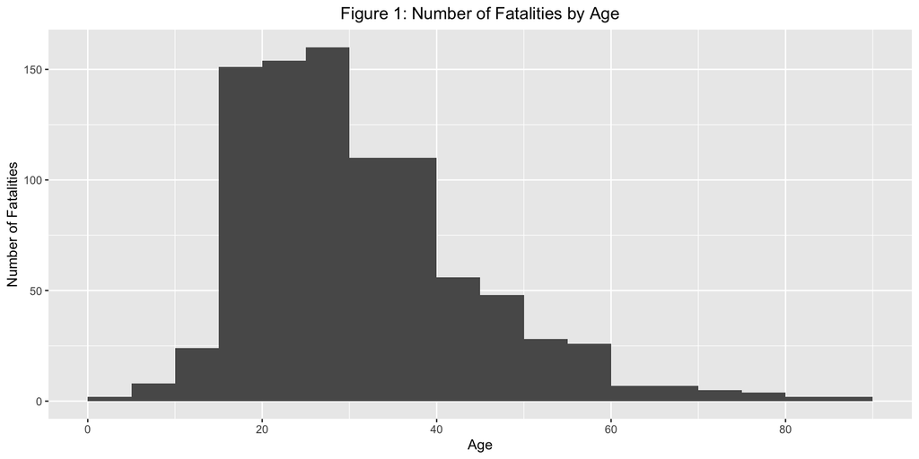

```r
ggplot(data = fallen1,
       aes(x = Age)) +
  geom_histogram(binwidth = 5,
                 boundary = 0) +
  scale_x_continuous(breaks = c(0, 20, 40, 60, 80, 100)) +
  # xlab("Age") +
  ylab("Number of Fatalities") +
  ggtitle("Figure 1: Number of Fatalities by Age") +
  theme(plot.title = element_text(hjust=0.5))
```

#### Bivariate/Multivariate Descriptive Figure

In the `conflicts` dataset, all conflicts are assigned codes for the group to which the conflict perpetrator and conflict target belong. Many conflicts have no specific target, in which case the conflict is coded as “sole action” of the perpetrator. There are 8 perpetrator groups to which the conflicts are ascribed, including “Military,” “Protesters,” and “Political Militia.”  
We can view the reported deaths resulting from conflicts from different perpetrators and perpetrator groups, but it is important to note that these fatalities do not necessarily belong to the conflict’s “target” group. For example, in conflicts instigated by protesters or rioters, it may be the case that most fatalities belonged to those groups. On the other hand, in the case of military or militia action, the deaths might have mostly occurred in the conflict target group.

[figure not shown]

```r
# Grouping number of fatalities per month
conflicts %>%
  group_by(month, perpetrator_group) %>%
  summarize(n.conflicts = n(),
            n.deadly.conflicts = sum(fatalities>0),
            fatalities = sum(fatalities), .groups = 'drop') %>%
  select(perpetrator_group, month, n.conflicts, n.deadly.conflicts, fatalities)  %>%

# Plotting monthly number of fatalities by perpetrator group
  ggplot(data = .,
         aes(x = month,
             y = n.deadly.conflicts,
             group = perpetrator_group,
             color = perpetrator_group)) +
  geom_point() +
  geom_line() +
  xlab("Month") +
  ylab("Number of Fatalities") +
  ggtitle("Figure 2: Number of Monthly Fatalities from events instigated by each Perpetrator Group") +
  scale_colour_discrete("Perpetrator Group") +
  theme(plot.title = element_text(hjust=0.5))
```

#### Trivariate Descriptive Figure

```r
detained_month_region <- detained %>%
  filter(`Region/State` == c('Ayeyarwaddy', 'Bago','Magwe', 'Mandalay','Sagaing',
                             'Taninthayi', 'Yangon', 'Kachin', 'Kayah', 'Kayin',
                             'Chin', 'Mon', 'Rakhine', 'Shan'),
         !is.na(month)) %>%
  group_by(month, `Region/State`) %>%
  summarize(monthly_region = n(), .groups = 'drop') %>%
  arrange(desc(monthly_region))
```

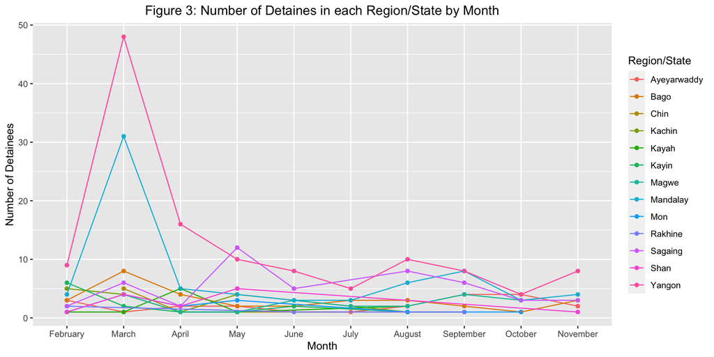

```r
ggplot(data = detained_month_region,
       aes(x = month,
           y=monthly_region,
           group = `Region/State`,
           color = `Region/State`)) +
  geom_point() +
  geom_line() +
  xlab("Month") +
  ylab("Number of Detainees") +
  ggtitle("Figure 3: Number of Detaines in each Region/State by Month") +
  theme(plot.title = element_text(hjust=0.5))
```

There were a total of 394 detainments that had proper State/Region and Month information out of the total of 6709 observations in the `detainees` dataset.

#### Statistical Tests

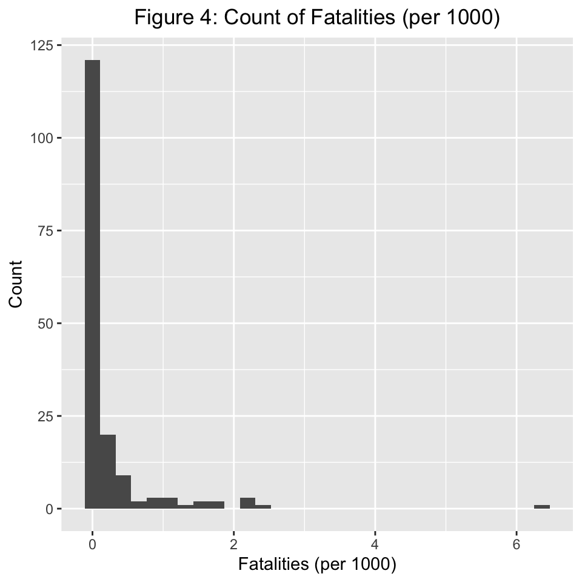

```r
# Sum the non-military conflicts, and calculate the fatalities per thousand.
hypothesis <- model.data %>%
  mutate(Fatalities.per.thousand = fatalities / Population.thousands,
         non_military = Rebels.conflicts + Political.militia.conflicts +
           Communal.militia.conflicts + Rioters.conflicts + Protesters.conflicts
          + Civilians.conflicts + Other.conflicts) %>%
  select(MIMU_township, Military.conflicts, non_military, Fatalities.per.thousand)

ggplot(data = hypothesis, aes(x = Fatalities.per.thousand)) +
  geom_histogram() +
  xlab("Fatalities (per 1000)") +
  ylab("Count") +
  ggtitle("Figure 4: Count of Fatalities (per 1000)") +
  theme(plot.title = element_text(hjust=0.5))
```

```r
# Create a table with level, if the fatalities per thousand is high or low
hyp.table <- hypothesis %>%
  mutate(level = case_when(Fatalities.per.thousand >= 0.5 ~ "High",
                           Fatalities.per.thousand < 0.5 ~ "Low")) %>%
  group_by(level) %>%
  summarize(Military = sum(Military.conflicts),
            Non_Military = sum(non_military))
```

```r
# Take the values from hyp.table to create a matrix for the Fisher test
hyp.table
```

```
## # A tibble: 3 × 3
##   level Military Non_Military
##   <chr>    <dbl>        <dbl>
## 1 High       801         1078
## 2 Low       1944         5238
## 3 <NA>        NA           NA
```

```r
conflicts.table <- as.table(rbind(c(801, 1078), c(1944, 5238)))
dimnames(conflicts.table) <- list("Fatality Rate" = c("High", "Low"),
                    "Conflict" = c("Military","Non-Military"))

f.test <- fisher.test(conflicts.table)

f.test
```

```
##
##  Fisher's Exact Test for Count Data
##
## data:  conflicts.table
## p-value < 2.2e-16
## alternative hypothesis: true odds ratio is not equal to 1
## 95 percent confidence interval:
##  1.799194 2.226890
## sample estimates:
## odds ratio
##   2.001949
```

Townships with high (greater than 0.5 fatalities/thousand) fatality rate, have higher odds of having a larger number of military conflicts, compared to non-military conflicts. Using our Fisher’s Exact Test for Count Data, high fatality townships had a 2 times greater odds of having more military conflicts than low fatality townships. These results are statistically significant, with a p-value of 0, which is less than the alpha value of 0.05.

#### Regression 1

Datasummary of the parameters considered for regression:

```r
datasummary_skim(data=model.data)
```

|  | Unique (#) | Missing (%) | Mean | SD | Min | Median | Max |  |
| --- | --- | --- | --- | --- | --- | --- | --- | --- |
| Imprisoned | 13 | 0 | 1.1 | 4.5 | 0.0 | 0.0 | 46.0 |  |
| Detained | 40 | 0 | 10.7 | 15.6 | 1.0 | 5.0 | 97.0 |  |
| Fallen | 22 | 0 | 4.2 | 9.8 | 0.0 | 1.0 | 75.0 |  |
| Total | 48 | 0 | 16.0 | 22.7 | 1.0 | 7.0 | 128.0 |  |
| Prop.Detained.Male | 48 | 0 | 0.8 | 0.3 | 0.0 | 0.9 | 1.0 |  |
| Population.thousands | 169 | 2 | 180.3 | 88.0 | 21.5 | 172.0 | 491.4 |  |
| conflicts | 99 | 2 | 53.9 | 56.0 | 2.0 | 36.0 | 289.0 |  |
| deadly.conflicts | 31 | 2 | 8.4 | 10.8 | 0.0 | 4.5 | 56.0 |  |
| prop.conflicts.deadly | 114 | 2 | 0.2 | 0.1 | 0.0 | 0.1 | 0.7 |  |
| fatalities | 60 | 2 | 28.8 | 53.7 | 0.0 | 8.0 | 302.0 |  |
| Military.conflicts | 55 | 2 | 16.3 | 20.9 | 0.0 | 9.0 | 138.0 |  |
| Rebels.conflicts | 19 | 2 | 2.1 | 8.0 | 0.0 | 0.0 | 63.0 |  |
| Political.militia.conflicts | 41 | 2 | 12.5 | 13.1 | 0.0 | 8.0 | 76.0 |  |
| Communal.militia.conflicts | 2 | 2 | 0.0 | 0.0 | 0.0 | 0.0 | 0.0 |  |
| Rioters.conflicts | 9 | 2 | 0.5 | 1.2 | 0.0 | 0.0 | 10.0 |  |
| Protesters.conflicts | 58 | 2 | 21.8 | 27.5 | 0.0 | 11.5 | 172.0 |  |
| Civilians.conflicts | 10 | 2 | 0.7 | 1.5 | 0.0 | 0.0 | 10.0 |  |
| Other.conflicts | 2 | 2 | 0.0 | 0.0 | 0.0 | 0.0 | 0.0 |  |
| Imprisoned.per.thousand | 31 | 2 | 0.0 | 0.0 | 0.0 | 0.0 | 0.1 |  |
| Detained.per.thousand | 169 | 2 | 0.1 | 0.1 | 0.0 | 0.0 | 0.9 |  |
| Fallen.per.thousand | 104 | 2 | 0.0 | 0.0 | 0.0 | 0.0 | 0.4 |  |

Linear Regression of factored conflicts on Detained.per.thousand:

```r
# Linear Regression of factored conflicts on Detained.per.thousand
det.lm <- lm(Detained.per.thousand ~ Population.thousands + Military.conflicts + Rebels.conflicts + Political.militia.conflicts + Rioters.conflicts + Protesters.conflicts + Civilians.conflicts, data = model.data, na.action = na.omit)

summary(det.lm)
```

```
##
## Call:
## lm(formula = Detained.per.thousand ~ Population.thousands + Military.conflicts +
##     Rebels.conflicts + Political.militia.conflicts + Rioters.conflicts +
##     Protesters.conflicts + Civilians.conflicts, data = model.data,
##     na.action = na.omit)
##
## Residuals:
##      Min       1Q   Median       3Q      Max
## -0.16995 -0.03469 -0.01274  0.01207  0.75253
##
## Coefficients:
##                               Estimate Std. Error t value Pr(>|t|)
## (Intercept)                  7.570e-02  1.517e-02   4.990 1.56e-06 ***
## Population.thousands        -2.752e-04  7.771e-05  -3.541 0.000523 ***
## Military.conflicts           6.179e-05  4.508e-04   0.137 0.891135
## Rebels.conflicts            -1.532e-03  1.015e-03  -1.509 0.133252
## Political.militia.conflicts  9.695e-04  6.655e-04   1.457 0.147153
## Rioters.conflicts            1.853e-02  5.892e-03   3.145 0.001982 **
## Protesters.conflicts         1.021e-03  3.028e-04   3.370 0.000941 ***
## Civilians.conflicts         -4.546e-03  5.641e-03  -0.806 0.421474
## ---
## Signif. codes:  0 '***' 0.001 '**' 0.01 '*' 0.05 '.' 0.1 ' ' 1
##
## Residual standard error: 0.08264 on 160 degrees of freedom
##   (3 observations deleted due to missingness)
## Multiple R-squared:  0.2421, Adjusted R-squared:  0.2089
## F-statistic: 7.301 on 7 and 160 DF,  p-value: 1.354e-07
```

Updated Linear Regression of factored conflicts on Detained.per.thousand (excluding `Political.militia.conflicts`):

```r
# Updating the linear regression by removing `Political.militia.conflicts`
det.lm.update <- update(det.lm, . ~ . - Political.militia.conflicts)
summary(det.lm.update)
```

```
##
## Call:
## lm(formula = Detained.per.thousand ~ Population.thousands + Military.conflicts +
##     Rebels.conflicts + Rioters.conflicts + Protesters.conflicts +
##     Civilians.conflicts, data = model.data, na.action = na.omit)
##
## Residuals:
##      Min       1Q   Median       3Q      Max
## -0.16777 -0.03575 -0.01360  0.01114  0.75532
##
## Coefficients:
##                        Estimate Std. Error t value Pr(>|t|)
## (Intercept)           7.795e-02  1.515e-02   5.147 7.64e-07 ***
## Population.thousands -2.608e-04  7.736e-05  -3.372 0.000936 ***
## Military.conflicts    3.831e-04  3.945e-04   0.971 0.332869
## Rebels.conflicts     -1.768e-03  1.006e-03  -1.758 0.080593 .
## Rioters.conflicts     1.987e-02  5.840e-03   3.402 0.000843 ***
## Protesters.conflicts  1.085e-03  3.006e-04   3.611 0.000406 ***
## Civilians.conflicts  -3.928e-03  5.645e-03  -0.696 0.487532
## ---
## Signif. codes:  0 '***' 0.001 '**' 0.01 '*' 0.05 '.' 0.1 ' ' 1
##
## Residual standard error: 0.08293 on 161 degrees of freedom
##   (3 observations deleted due to missingness)
## Multiple R-squared:  0.232,  Adjusted R-squared:  0.2034
## F-statistic: 8.107 on 6 and 161 DF,  p-value: 1.156e-07
```

```r
# Summary of the linear regression model
summary1 <- summary(det.lm)
summary2 <- summary(det.lm.update)

# Pulling out specific values from summary table
RC.pval <- round(summary1$coef["Rioters.conflicts", "Pr(>|t|)"], 6)
RC.update.pval <- round(summary2$coef["Rioters.conflicts", "Pr(>|t|)"], 6)
RC.update.est <- round(summary2$coef["Rioters.conflicts", "Estimate"], 6)

PC.pval <- round(summary1$coef["Protesters.conflicts", "Pr(>|t|)"], 6)
PC.update.pval <- round(summary2$coef["Protesters.conflicts", "Pr(>|t|)"], 6)
PC.update.est <- round(summary2$coef["Protesters.conflicts", "Estimate"], 6)


PopT.pval <- round(summary1$coef["Population.thousands", "Pr(>|t|)"], 6)
PopT.update.pval <- round(summary2$coef["Population.thousands", "Pr(>|t|)"], 6)
PopT.update.est <- round(summary2$coef["Population.thousands", "Estimate"], 6)
```

##### Assesment for Colinearity

The following plot matrix (pairs function) is used to diagnose collinearity among the variables.

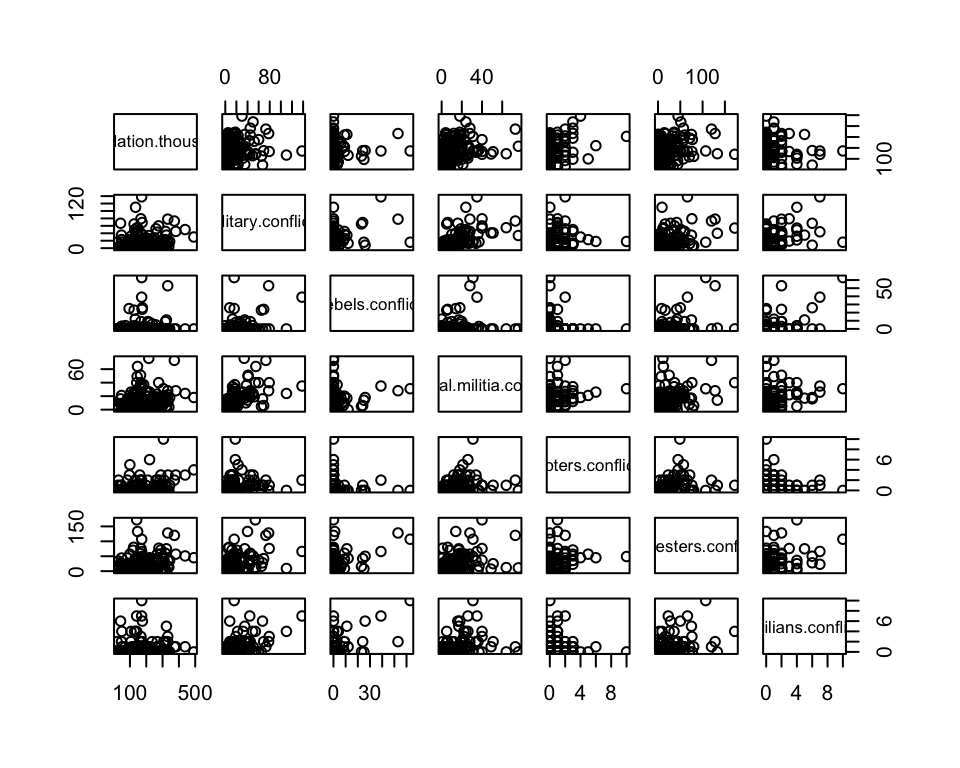

```r
det.values <- c("Population.thousands", "Military.conflicts", "Rebels.conflicts", "Political.militia.conflicts", "Rioters.conflicts", "Protesters.conflicts", "Civilians.conflicts")

# Pairs function
model.data %>%
  select(all_of(det.values)) %>%
  pairs()
```

##### Regression Diagnostics 1

The following four plots are important diagnostic tools in assessing whether the linear model is appropriate.

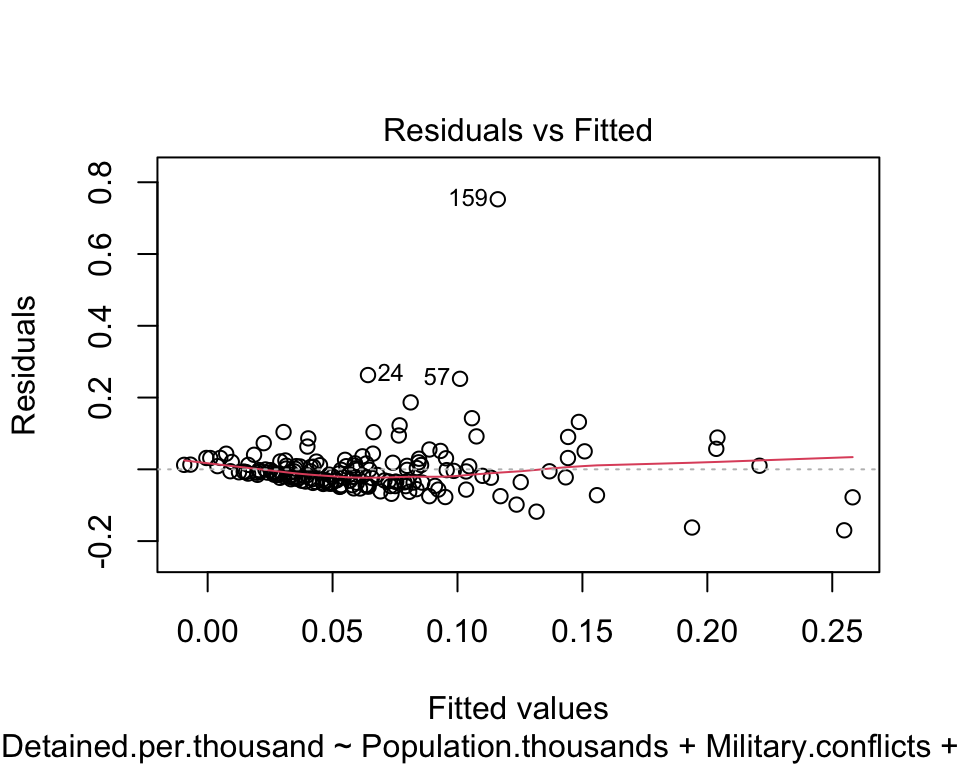

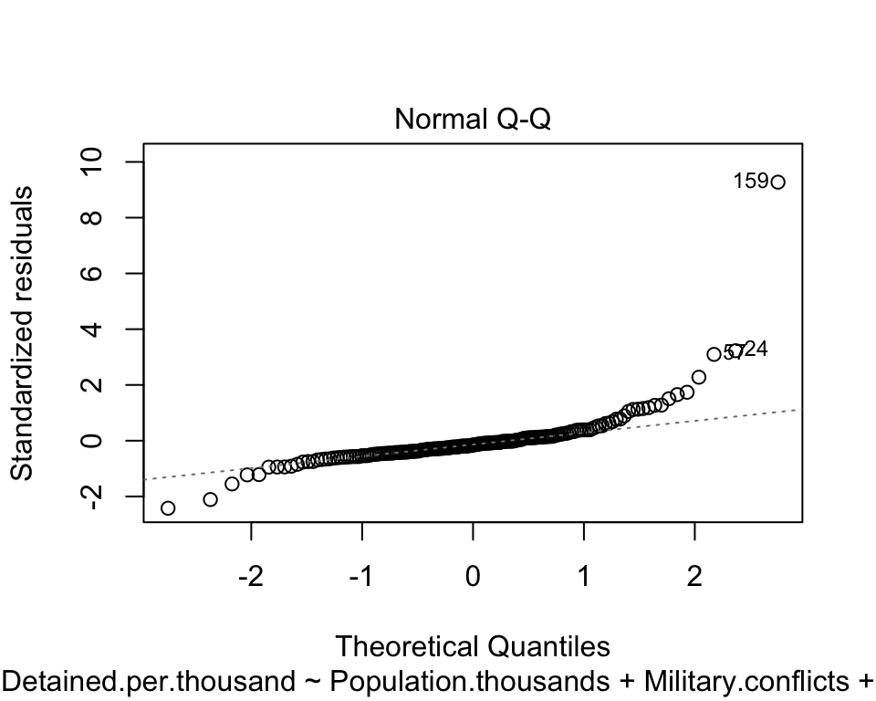

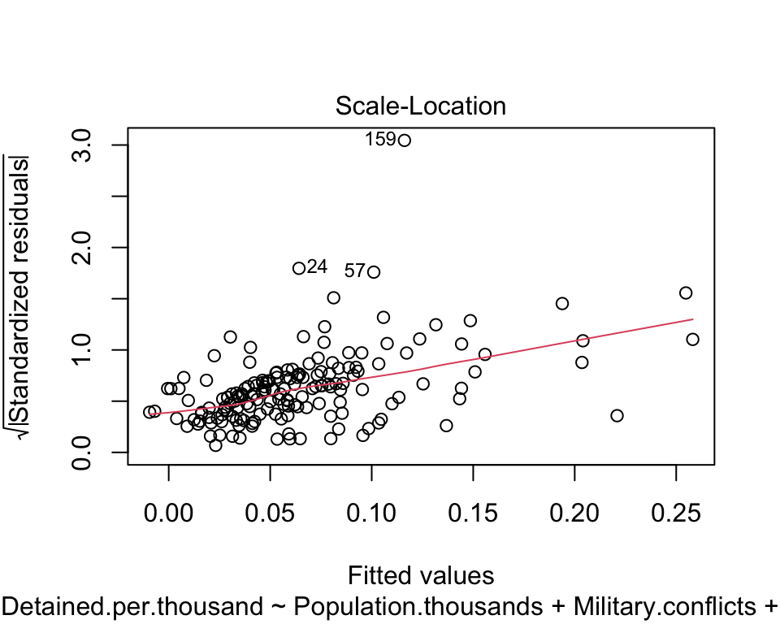

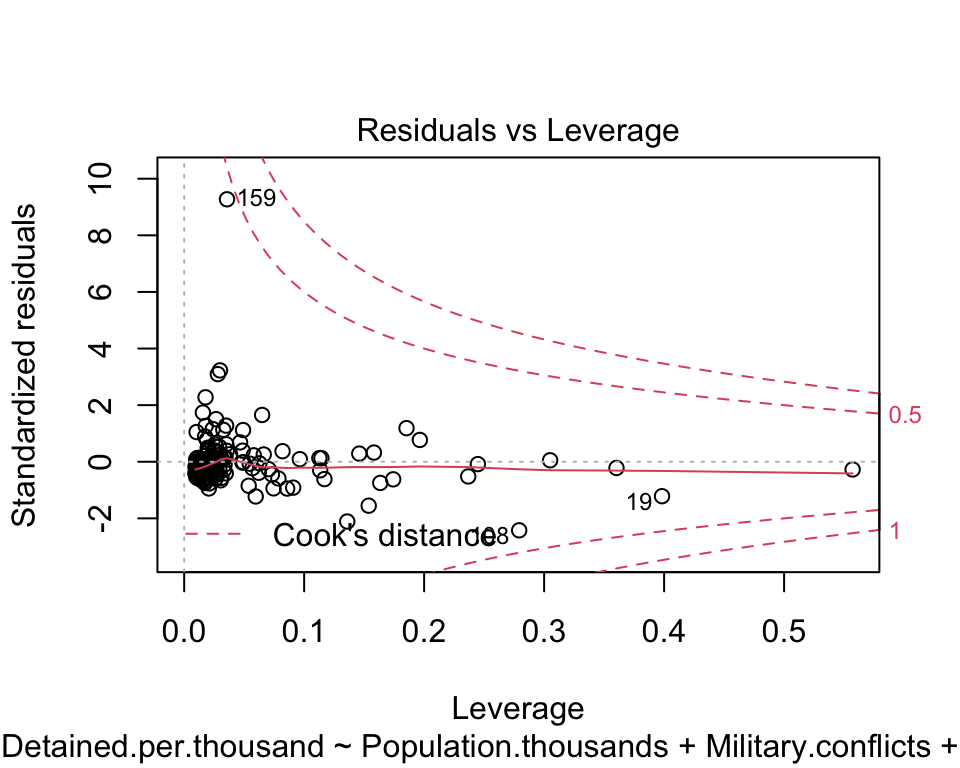

```r
# Diagnostics Plots
plot(det.lm)
```

##### Interpretation of Linear Regression 1

Looking at the plot, we see some of the variables are correlated. In particular, `Military.conflicts` and `Political.militia.conflicts` demonstrate a correlation of 0.625938. Furthermore, `Protesters.conflicts` and `Political.militia.conflicts` demonstrate a correlation of 0.4406758. For this reason, `Political.militia.conflicts` was removed from this linear regression and the linear model was updated.

Now, looking at those variables in more detail, all else being equal between two states, a 1-unit increase in `Population.thousands` appears to be associated with a 2.61^{-4} decrease in `Detained.per.thousand`. On the other hand, a 1-unit increase in `Rioters.conflicts` appears to be associated with a 0.019868 increase in `Detained.per.thousand` while a a 1-unit increase in `Protesters.conflicts` appears to be associated with a 0.001085 increase in `Detained.per.thousand`.

#### Regression 2

Linear Regression of factored conflicts on Detained.per.thousand and Sex:

```r
# Linear Regression of factored conflicts on Detained.per.thousand
det.lm2 <- lm(Detained.per.thousand ~ Population.thousands +
                Military.conflicts + Rebels.conflicts +
                Rioters.conflicts + Civilians.conflicts +
               Prop.Detained.Male, data = model.data, na.action = na.omit)

# Summary of the linear regression model
summary(det.lm2)
```

```
##
## Call:
## lm(formula = Detained.per.thousand ~ Population.thousands + Military.conflicts +
##     Rebels.conflicts + Rioters.conflicts + Civilians.conflicts +
##     Prop.Detained.Male, data = model.data, na.action = na.omit)
##
## Residuals:
##      Min       1Q   Median       3Q      Max
## -0.17276 -0.03852 -0.01713  0.01347  0.77728
##
## Coefficients:
##                        Estimate Std. Error t value Pr(>|t|)
## (Intercept)           7.630e-02  2.477e-02   3.080  0.00243 **
## Population.thousands -2.202e-04  7.957e-05  -2.768  0.00630 **
## Military.conflicts    7.087e-04  3.993e-04   1.775  0.07784 .
## Rebels.conflicts     -9.063e-04  1.024e-03  -0.885  0.37743
## Rioters.conflicts     2.638e-02  5.772e-03   4.571 9.63e-06 ***
## Civilians.conflicts  -8.214e-04  5.854e-03  -0.140  0.88858
## Prop.Detained.Male    6.541e-03  2.487e-02   0.263  0.79285
## ---
## Signif. codes:  0 '***' 0.001 '**' 0.01 '*' 0.05 '.' 0.1 ' ' 1
##
## Residual standard error: 0.0862 on 161 degrees of freedom
##   (3 observations deleted due to missingness)
## Multiple R-squared:  0.1702, Adjusted R-squared:  0.1392
## F-statistic: 5.503 on 6 and 161 DF,  p-value: 3.301e-05
```

```r
# Add coefficients to new data
det.lm2.coef <- round(summary(det.lm2)$coef, 3)
```

##### Assesment for Colinearity

The following plot matrix (pairs function) is used to diagnose collinearity among the variables.

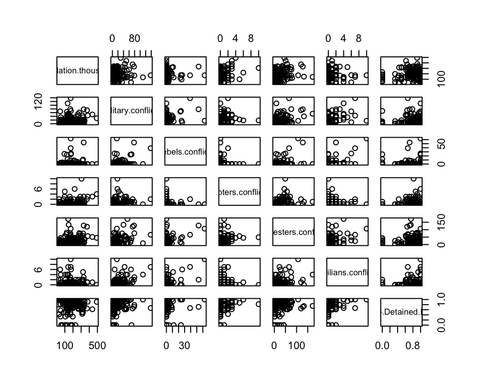

```r
# Drop Political.militia.conflicts from the values because they are highly colinear with military.conflicts.

det.values2 <- c("Population.thousands", "Military.conflicts",
                 "Rebels.conflicts", "Rioters.conflicts",
                 "Protesters.conflicts", "Civilians.conflicts", "Prop.Detained.Male")

model.data %>%
  select(all_of(det.values2)) %>%
  pairs()
```

##### Regression Diagnostics 2

The following four plots are important diagnostic tools in assessing whether the linear model is appropriate.

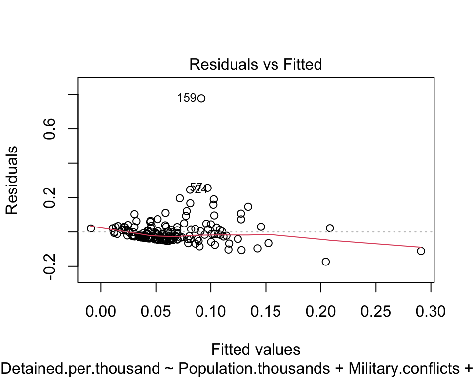

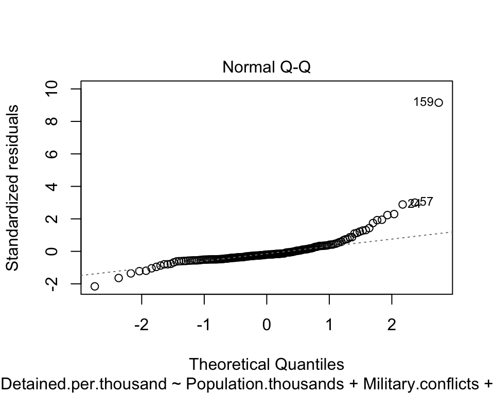

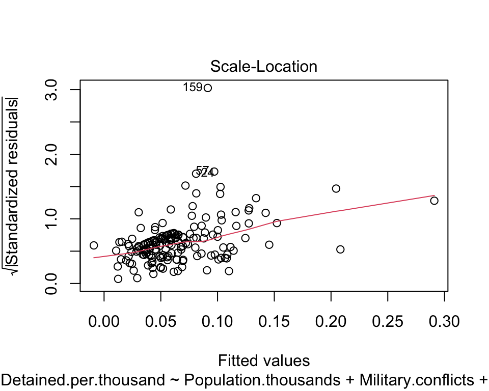

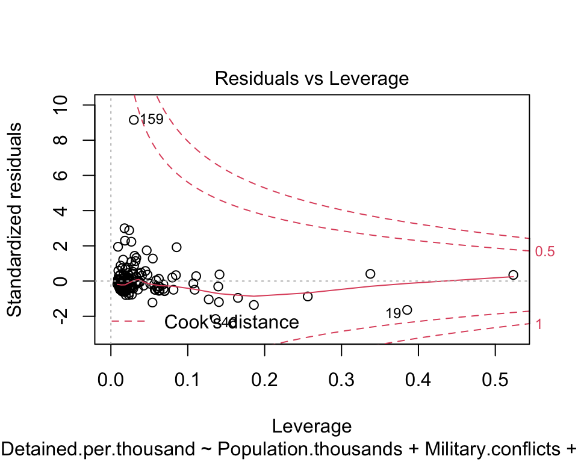

```r
plot(det.lm2)
```

##### Interpretation for Linear Regression 2

For this regression, we decided to add the proportion of male detainees into our previous regression. We wanted to see if there was a relationship between the proportion males had an affect on the number of detainees per thousand of population. Similar to the last regression, we tested for collinearity to get statistically significant coefficients.

Our assessment of collinearity showed that Political.militia.conflicts and military.conflicts were highly collinear, therefore the former is not included in our regression. We used the pair plot to see if there are any highly collinear variables for this regression. The proportion of males and military conflicts although appeared highly correlated, was not with a correlation of 0.0411372. We included both of these in our model. However, military conflicts and protester conflicts we’re relatively collinear, with a correlation of 0.4909195. Therefore, we removed Protesters.conflicts to see if this changed the significance of our variables in the regression.

The only statistically significant variables were Population.thousands (p = 0.006). Holding all other variables constant, every one unit increase of Population.thousands results in a 2.2022771^{-4} decrease in the number of detainees in a township per 1000 of population.

The other statistically significant variable is Rioters.conflicts (p = 0). Holding all other variables constant, every one unit increase in the number of Rioters.conflicts results in a 0.0263832 increase in the number of detainees in a township per 1000 of population.

These numbers are not particularly interpretable because the units for each variable (including our target variable) are in different proportions (e.g. detainees per 1000). All other variables are not statistically significant at the 0.05 significant level.

### Discussion

Our Fisher’s test and regression analysis show that there are some significant relationships between the violent conflict events (in the conflict datasets), to the number of detainees by township. These relationships are not consistent, meaning that not all conflict event types are statistically significant in these analyses. Our regressions did show that an increase in the population size resulted in a decrease in the number of detainees per 1000 of population. This suggests that smaller townships are facing more political violence from various agents, and those populations are facing higher rates of detainment. It is interesting to note that the number of detainments was the highest earlier in the year, but the number of conflicts was at its peak in the last few months of the year. One potential alternative analysis that we could run in the future is if there is a correlation, by month, on the number of deadly conflicts, by the number of detainees.

This situation in Myanmar is politically sensitive. The human rights violations are extremely concerning, and the lives lost are saddening. However, we have to recognize that the scale at which this information is relevant can only come at the international level. Accountability on the international stage will be crucial so that the people who have been directly and indirectly affected by the mass violence in Myanmar for the past year can begin to heal. This data can help with potential international intervention in the region. Although we focused this analysis at the township level, regional level analysis could be useful to identify regions in dire need. This could be an opportunity for humanitarian aid in these regions from neighboring countries in Southeast Asia, international organizations like the United Nations, or other human rights organizations.

This data was challenging to navigate. The pros and cons of real-world data were very evident. Although thorough in some ways, doing a township-level analysis highlighted some of the data consistency issues with these datasets. For example, factors like age were missing in most datasets, with the exception of the `fallen` dataset. This was challenging because our group thought it would be an interesting idea to study if there was a generational difference in political activism. However, we we’re unable to use just the `fallen` dataset because it felt incomplete to the entire dataset. We only looked at one aspect of the MIMU dataset (population). One of the potential visualizations we were thinking about doing was a population pyramid of Myanmar according to gender and different age brackets. If we had robust `age` data, then this would be interesting to use in the analysis. The `apply_leven` function was helpful in mapping townships, but it was limited because of the way that certain townships/addresses were recorded. For example, the first detainee was the infamous Aung San Suu Kyi, however her township was not mapped by the `apply_leven` function and she remained out of our joined data. One positive of this dataset was that we were able to extract a large enough sample (greater than 30) for the townships that did map correctly.